# Reproducible Research: Peer Assessment 1

We’ll be taking advantage of the `lubridate` package to ease working with dates.

```r
library(lubridate)
```

## Loading and preprocessing the data

We read the csv, and take a copy of the data subset to complete cases only.

```r
act_data <- read.csv("activity.csv")
act_complete <- act_data[complete.cases(act_data),]
```

## What is the mean total number of steps taken per day?

First we’ll take a look at the break down of steps taken per day with `NA` values removed.

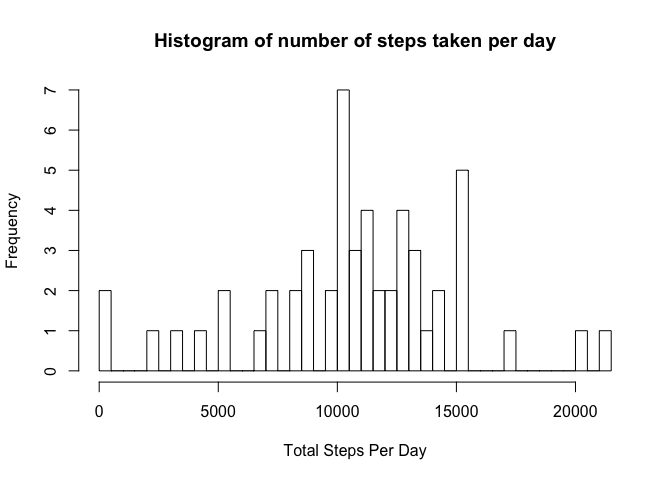

```r
# Group the steps by date and sum all the steps taken on each day
by_steps <- by(act_complete$steps, act_complete$date, FUN = sum)

hist(by_steps,
     breaks = length(unique(by_steps)),
     main   = "Histogram of number of steps taken per day",
     xlab = "Total Steps Per Day")
```

The mean of the steps taken per day is

```r
mean(by_steps, na.rm = TRUE)
```

```
## [1] 10766.19
```

The median of the steps taken per day is

```r
median(by_steps, na.rm = TRUE)
```

```
## [1] 10765
```

## What is the average daily activity pattern?

The average daily activity pattern is rendered from our complete case data, taking the mean number of steps over each interval.

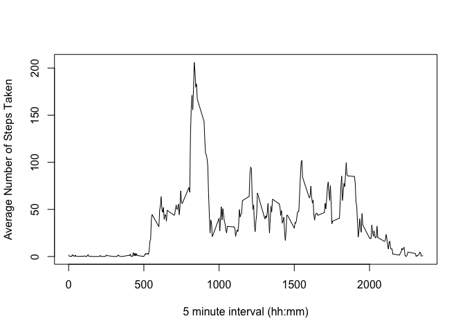

```r
mean_interval <- tapply(act_complete$steps, act_complete$interval, mean)
plot(names(mean_interval),
     mean_interval,
     type = "l",
     xlab = "5 minute interval (hh:mm)",
     ylab = "Average Number of Steps Taken")
```

#### Interval with maximum average number of steps

```r
time <- names(which.max(mean_interval))
# Pad the time to 4 places by prefixing with 0s then parse to lubridate
lubtime <- parse_date_time(sprintf("%04s", time), "H!M!")
# Concatenate the parts into a readable format.
form_time <- paste(hour(lubtime), ":", minute(lubtime), sep = "")
```

This tells us that the interval with the maximum average steps at approx. 206 steps is **8:35**.